# Introduction to matplotlib - Exercises solutions

```python
import warnings
warnings.filterwarnings('ignore')

import pandas as pd
import numpy as np
import matplotlib.pyplot as plt
import seaborn as sns
```

```python
plt.rcParams['figure.figsize']=6,6
```

### Exercise 1

We will work with the `diamonds` dataset. The dataset is available through the `seaborn` package. You will have to run the following: `diamonds = sns.load_dataset('diamonds')`. For all the plots use a customed style of your choice.

- Create a scatter plot with the `carat` on the x axis and the `price` variable on the y axis. Label the axis appropriately.
- Create the same scatter plot as above, but this type use a different colour for each `cut` value. Label the axis appropriately and include a legend.
- Create a bar chart showing the price for the different colours. Add also standard error bars. Add also standard error bars. To calculate the standard error of the mean you can use the `scipy.stats.sem`.
- Create a stacked bar chart including the mean values of the `x`, `y` and `z` columns for each clarity value.
- Create a boxplot with the price range for the different `cut` values.
- Calculate the Pearson correlations amongst all numeric columns. Create a heatmap plot from the correlation matrix, including a colour bar showing the range of colours for the corresponding correlation values.

```python
diamonds = sns.load_dataset('diamonds')
diamonds
```

|  | carat | cut | color | clarity | depth | table | price | x | y | z |
| --- | --- | --- | --- | --- | --- | --- | --- | --- | --- | --- |
| 0 | 0.23 | Ideal | E | SI2 | 61.5 | 55.0 | 326 | 3.95 | 3.98 | 2.43 |
| 1 | 0.21 | Premium | E | SI1 | 59.8 | 61.0 | 326 | 3.89 | 3.84 | 2.31 |
| 2 | 0.23 | Good | E | VS1 | 56.9 | 65.0 | 327 | 4.05 | 4.07 | 2.31 |
| 3 | 0.29 | Premium | I | VS2 | 62.4 | 58.0 | 334 | 4.20 | 4.23 | 2.63 |
| 4 | 0.31 | Good | J | SI2 | 63.3 | 58.0 | 335 | 4.34 | 4.35 | 2.75 |
| ... | ... | ... | ... | ... | ... | ... | ... | ... | ... | ... |
| 53935 | 0.72 | Ideal | D | SI1 | 60.8 | 57.0 | 2757 | 5.75 | 5.76 | 3.50 |
| 53936 | 0.72 | Good | D | SI1 | 63.1 | 55.0 | 2757 | 5.69 | 5.75 | 3.61 |
| 53937 | 0.70 | Very Good | D | SI1 | 62.8 | 60.0 | 2757 | 5.66 | 5.68 | 3.56 |
| 53938 | 0.86 | Premium | H | SI2 | 61.0 | 58.0 | 2757 | 6.15 | 6.12 | 3.74 |
| 53939 | 0.75 | Ideal | D | SI2 | 62.2 | 55.0 | 2757 | 5.83 | 5.87 | 3.64 |

53940 rows × 10 columns

```python
diamonds.info()
```

```
<class 'pandas.core.frame.DataFrame'>
RangeIndex: 53940 entries, 0 to 53939
Data columns (total 10 columns):
 #   Column   Non-Null Count  Dtype
---  ------   --------------  -----
 0   carat    53940 non-null  float64
 1   cut      53940 non-null  category
 2   color    53940 non-null  category
 3   clarity  53940 non-null  category
 4   depth    53940 non-null  float64
 5   table    53940 non-null  float64
 6   price    53940 non-null  int64
 7   x        53940 non-null  float64
 8   y        53940 non-null  float64
 9   z        53940 non-null  float64
dtypes: category(3), float64(6), int64(1)
memory usage: 3.0 MB
```

```python
plt.style.use('seaborn-v0_8-colorblind')
```

Create a scatter plot with the `carat` on the x axis and the `price` variable on the y axis.

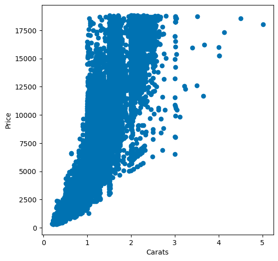

```python
fig, ax = plt.subplots()
ax.scatter(diamonds['carat'],diamonds['price'])
ax.set_xlabel('Carats')
ax.set_ylabel('Price')
```

Create the same scatter plot as above, but this type use a different colour for each `cut` value.

```python
colours = ['blue','cyan', 'purple', 'green', 'orange']
cut_options = diamonds['cut'].unique()
cut_colours = list(zip(cut_options,colours))
cut_colours
```

```
[('Ideal', 'blue'),
 ('Premium', 'cyan'),
 ('Good', 'purple'),
 ('Very Good', 'green'),
 ('Fair', 'orange')]
```

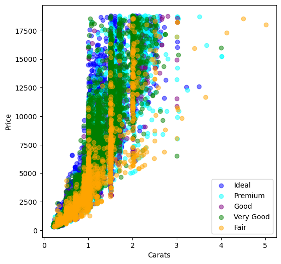

```python
fig, ax = plt.subplots()
for value, colour in cut_colours:
    ax.scatter(diamonds[diamonds['cut']==value]['carat'], diamonds[diamonds['cut']==value]['price'],c=colour, alpha=0.5,label=value)
ax.set_xlabel('Carats')
ax.set_ylabel('Price')
ax.legend()
```

Create a bar chart showing the price for the different colours. Add also standard error bars. To calculate the standard error of the mean you can use the `scipy.stats.sem`.

```python
from scipy.stats import sem
diamonds_summary = diamonds.groupby('color')['price'].agg([np.mean,sem])
diamonds_summary
```

| color | mean | sem |
| --- | --- | --- |
| D | 3169.954096 | 40.779676 |
| E | 3076.752475 | 33.786276 |
| F | 3724.886397 | 38.747640 |
| G | 3999.135671 | 38.123067 |
| H | 4486.669196 | 46.264852 |
| I | 5091.874954 | 64.133047 |
| J | 5323.818020 | 83.754292 |

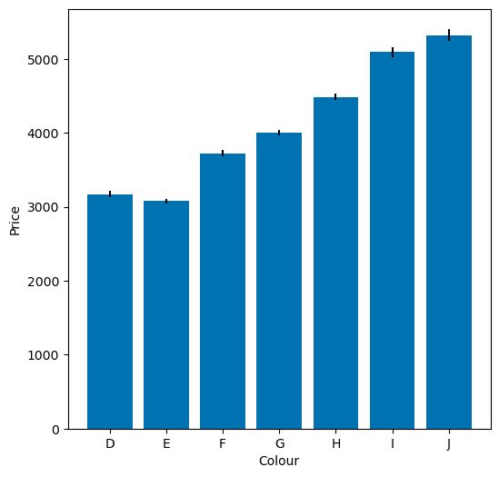

```python
fig, ax = plt.subplots()
ax.bar(diamonds_summary.index, diamonds_summary['mean'], yerr=diamonds_summary['sem'])
ax.set_xlabel('Colour')
ax.set_ylabel('Price')
```

Create a stacked bar chart including the mean values of the `x`, `y` and `z` columns for each clarity value.

```python
clarity_summary = diamonds.groupby('clarity')[['x','y','z']].mean()
clarity_summary
```

| clarity | x | y | z |
| --- | --- | --- | --- |
| IF | 4.968402 | 4.989827 | 3.061659 |
| VVS1 | 4.960364 | 4.975075 | 3.061294 |
| VVS2 | 5.218454 | 5.232118 | 3.221465 |
| VS1 | 5.572178 | 5.581828 | 3.441007 |
| VS2 | 5.657709 | 5.658859 | 3.491478 |
| SI1 | 5.888383 | 5.888256 | 3.639845 |
| SI2 | 6.401370 | 6.397826 | 3.948478 |
| I1 | 6.761093 | 6.709379 | 4.207908 |

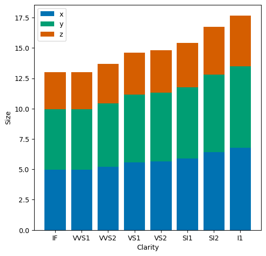

```python
fig, ax = plt.subplots()
ax.bar(clarity_summary.index, clarity_summary['x'], label='x')
ax.bar(clarity_summary.index, clarity_summary['y'], bottom=clarity_summary['x'], label='y')
ax.bar(clarity_summary.index, clarity_summary['z'],
       bottom=clarity_summary['x'] + clarity_summary['y'], label='z')
ax.set_xlabel('Clarity')
ax.set_ylabel('Size')
ax.legend()
```

Create a boxplot with the price range for the different `cut` values.

```python
cut_options
```

```
['Ideal', 'Premium', 'Good', 'Very Good', 'Fair']
Categories (5, object): ['Ideal', 'Premium', 'Very Good', 'Good', 'Fair']
```

```python
diamonds_ideal = diamonds[diamonds['cut']=='Ideal']['price']
diamonds_premium = diamonds[diamonds['cut']=='Premium']['price']
diamonds_good = diamonds[diamonds['cut']=='Good']['price']
diamonds_very_good = diamonds[diamonds['cut']=='Very Good']['price']
diamonds_fair = diamonds[diamonds['cut']=='Fair']['price']
```

```python
diamonds_ideal
```

```
0         326
11        340
13        344
16        348
39        403
         ...
53925    2756
53926    2756
53929    2756
53935    2757
53939    2757
Name: price, Length: 21551, dtype: int64
```

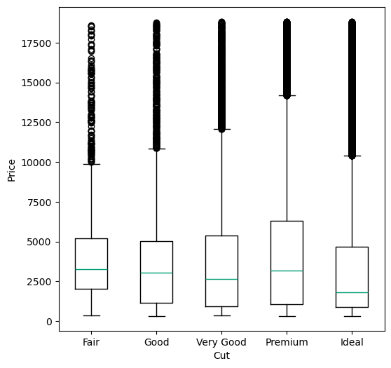

```python
fig, ax = plt.subplots()
ax.boxplot([diamonds_fair,diamonds_good,diamonds_very_good,diamonds_premium,diamonds_ideal])
ax.set_xticklabels(['Fair','Good','Very Good','Premium','Ideal'])
ax.set_xlabel('Cut')
ax.set_ylabel('Price')
```

Calculate the Pearson correlations amongst all numeric columns. Create a heatmap plot from the correlation matrix, including a colour bar showing the range of colours for the corresponding correlation values.

```python
diamonds.info()
```

```
<class 'pandas.core.frame.DataFrame'>
RangeIndex: 53940 entries, 0 to 53939
Data columns (total 10 columns):
 #   Column   Non-Null Count  Dtype
---  ------   --------------  -----
 0   carat    53940 non-null  float64
 1   cut      53940 non-null  category
 2   color    53940 non-null  category
 3   clarity  53940 non-null  category
 4   depth    53940 non-null  float64
 5   table    53940 non-null  float64
 6   price    53940 non-null  int64
 7   x        53940 non-null  float64
 8   y        53940 non-null  float64
 9   z        53940 non-null  float64
dtypes: category(3), float64(6), int64(1)
memory usage: 3.0 MB
```

```python
corr_mat = diamonds.loc[:,["carat","depth","table","price","x","y","z"]].corr()
corr_mat
```

|  | carat | depth | table | price | x | y | z |
| --- | --- | --- | --- | --- | --- | --- | --- |
| carat | 1.000000 | 0.028224 | 0.181618 | 0.921591 | 0.975094 | 0.951722 | 0.953387 |
| depth | 0.028224 | 1.000000 | -0.295779 | -0.010647 | -0.025289 | -0.029341 | 0.094924 |
| table | 0.181618 | -0.295779 | 1.000000 | 0.127134 | 0.195344 | 0.183760 | 0.150929 |
| price | 0.921591 | -0.010647 | 0.127134 | 1.000000 | 0.884435 | 0.865421 | 0.861249 |
| x | 0.975094 | -0.025289 | 0.195344 | 0.884435 | 1.000000 | 0.974701 | 0.970772 |
| y | 0.951722 | -0.029341 | 0.183760 | 0.865421 | 0.974701 | 1.000000 | 0.952006 |
| z | 0.953387 | 0.094924 | 0.150929 | 0.861249 | 0.970772 | 0.952006 | 1.000000 |

[output not shown]

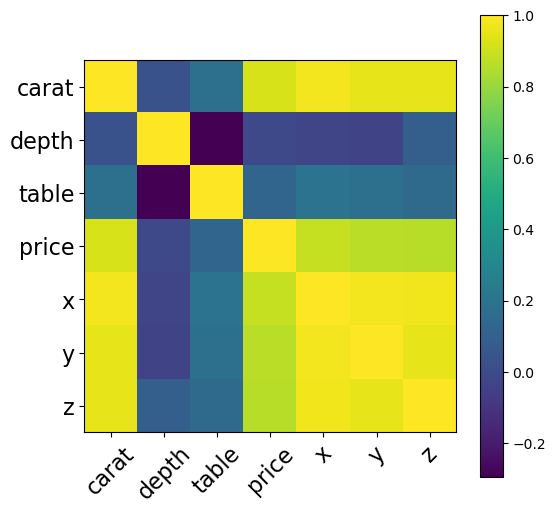

```python
labels = ["carat", "depth", "table", "price", "x", "y", "z"]
fig, ax = plt.subplots()
diamonds_heatmap = ax.imshow(corr_mat)
plt.colorbar(diamonds_heatmap)
tick_marks = np.arange(len(labels))
plt.xticks(tick_marks, labels,fontsize=16, rotation=45)
plt.yticks(tick_marks, labels, fontsize=16)
```

### Exercise 2

We will work with the `snp_variants.txt` dataset. For all the plots use a customed style of your choice.

```python
snp_variants = pd.read_csv('snp_variants.txt', sep='\t')
snp_variants.info()
```

```
<class 'pandas.core.frame.DataFrame'>
RangeIndex: 465 entries, 0 to 464
Data columns (total 4 columns):
 #   Column      Non-Null Count  Dtype
---  ------      --------------  -----
 0   Chromosome  465 non-null    object
 1   Position    465 non-null    int64
 2   Id          465 non-null    object
 3   Reference   465 non-null    object
dtypes: int64(1), object(3)
memory usage: 14.7+ KB
```

```python
snp_variants
```

|  | Chromosome | Position | Id | Reference |
| --- | --- | --- | --- | --- |
| 0 | NC_036838.1 | 130081 | 139:7:+ | T |
| 1 | NC_036838.1 | 129969 | 140:110:- | G |
| 2 | NC_036838.1 | 296862 | 367:366:- | G |
| 3 | NC_036838.1 | 351267 | 474:292:- | A |
| 4 | NC_036838.1 | 642578 | 886:28:- | A |
| ... | ... | ... | ... | ... |
| 460 | NC_036840.1 | 34048972 | 348117:67:- | T |
| 461 | NC_036840.1 | 34340755 | 348682:32:- | C |
| 462 | NC_036840.1 | 34636457 | 349008:112:- | A |
| 463 | NC_036840.1 | 35422608 | 350283:307:- | G |
| 464 | NC_036840.1 | 35815509 | 350843:8:- | C |

465 rows × 4 columns

Create a horizontal bar chart with the number of SNP variants of each chromosome.

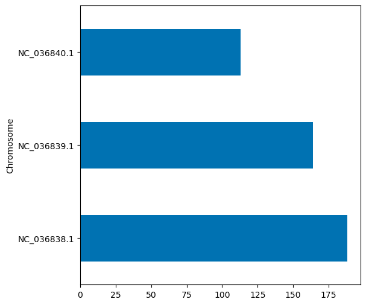

```python
snp_variants.groupby('Chromosome').size().plot(kind='barh')
```

Create separate line plots for each chromosome depicting the base composition of the `Reference` column along non-overlapping windows of 10,000,000 base pairs (you will need to estimate the occurences each base [A,G,C,T] for every ten million base pairs). Save the plot in a pdf format.

```python
chromosome = snp_variants['Chromosome'].unique()
chromosome
```

```
array(['NC_036838.1', 'NC_036839.1', 'NC_036840.1'], dtype=object)
```

```python
snp_first_chrom = snp_variants[snp_variants['Chromosome']==chromosome[0]]
bases_chr1 = {'A':[0], 'G':[0], 'C':[0], 'T':[0]}
for i in range(0,snp_first_chrom['Position'].max(), 10000000):
    win_variants = snp_first_chrom[(snp_first_chrom['Position'] >= i)
                                   & (snp_first_chrom['Position'] <= i + 10000000)]['Reference']
    for base in 'AGCT':
        bases_chr1[base].append(win_variants.value_counts()[base]/win_variants.value_counts().sum())
```

```python
chrom1_regions = [i for i in range(0,snp_first_chrom['Position'].max()+10000000, 10000000)]
chrom1_regions
```

```
[0, 10000000, 20000000, 30000000, 40000000, 50000000, 60000000]
```

```python
bases_chr1.update({'Position':chrom1_regions})
bases_chr1 = pd.DataFrame(bases_chr1)
bases_chr1
```

|  | A | G | C | T | Position |
| --- | --- | --- | --- | --- | --- |
| 0 | 0.000000 | 0.000000 | 0.000000 | 0.000000 | 0 |
| 1 | 0.137931 | 0.275862 | 0.310345 | 0.275862 | 10000000 |
| 2 | 0.206897 | 0.310345 | 0.206897 | 0.275862 | 20000000 |
| 3 | 0.214286 | 0.333333 | 0.261905 | 0.190476 | 30000000 |
| 4 | 0.250000 | 0.343750 | 0.250000 | 0.156250 | 40000000 |
| 5 | 0.193548 | 0.290323 | 0.354839 | 0.161290 | 50000000 |
| 6 | 0.160000 | 0.240000 | 0.320000 | 0.280000 | 60000000 |

```python
snp_second_chrom = snp_variants[snp_variants['Chromosome']==chromosome[1]]
bases_chr2 = {'A':[0], 'G':[0], 'C':[0], 'T':[0]}
for i in range(0,snp_second_chrom['Position'].max(), 10000000):
    win_variants = snp_second_chrom[(snp_second_chrom['Position'] >= i) & (snp_second_chrom['Position'] <= i + 10000000)]['Reference']
    for base in 'AGCT':
        bases_chr2[base].append(win_variants.value_counts()[base]/win_variants.value_counts().sum())
```

```python
chrom2_regions = [i for i in range(0,snp_second_chrom['Position'].max()+10000000, 10000000)]
chrom2_regions
```

```
[0, 10000000, 20000000, 30000000, 40000000, 50000000]
```

```python
bases_chr2.update({'Position':chrom2_regions})
bases_chr2 = pd.DataFrame(bases_chr2)
bases_chr2
```

|  | A | G | C | T | Position |
| --- | --- | --- | --- | --- | --- |
| 0 | 0.000000 | 0.000000 | 0.000000 | 0.000000 | 0 |
| 1 | 0.134615 | 0.288462 | 0.230769 | 0.346154 | 10000000 |
| 2 | 0.217391 | 0.217391 | 0.260870 | 0.304348 | 20000000 |
| 3 | 0.166667 | 0.266667 | 0.300000 | 0.266667 | 30000000 |
| 4 | 0.347826 | 0.130435 | 0.130435 | 0.391304 | 40000000 |
| 5 | 0.307692 | 0.076923 | 0.307692 | 0.307692 | 50000000 |

```python
snp_third_chrom = snp_variants[snp_variants['Chromosome']==chromosome[2]]
bases_chr3 = {'A':[0], 'G':[0], 'C':[0], 'T':[0]}
for i in range(0,snp_third_chrom['Position'].max(), 10000000):
    win_variants = snp_third_chrom[(snp_third_chrom['Position'] >= i) & (snp_third_chrom['Position'] <= i+10000000)]['Reference']
    for base in 'AGCT':
        bases_chr3[base].append(win_variants.value_counts()[base]/win_variants.value_counts().sum())
```

```python
chrom3_regions = [i for i in range(0,snp_third_chrom['Position'].max()+10000000, 10000000)]
chrom3_regions
```

```
[0, 10000000, 20000000, 30000000, 40000000]
```

```python
bases_chr3.update({'Position':chrom3_regions})
bases_chr3 = pd.DataFrame(bases_chr3)
bases_chr3
```

|  | A | G | C | T | Position |
| --- | --- | --- | --- | --- | --- |
| 0 | 0.000000 | 0.000000 | 0.000000 | 0.000000 | 0 |
| 1 | 0.266667 | 0.233333 | 0.333333 | 0.166667 | 10000000 |
| 2 | 0.264706 | 0.235294 | 0.264706 | 0.235294 | 20000000 |
| 3 | 0.193548 | 0.419355 | 0.129032 | 0.258065 | 30000000 |
| 4 | 0.222222 | 0.277778 | 0.388889 | 0.111111 | 40000000 |

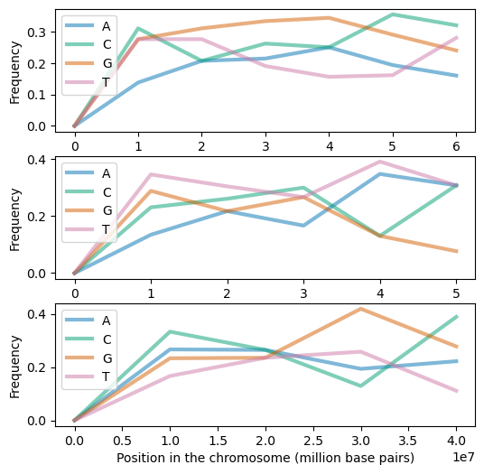

```python
fig, ax = plt.subplots(3,1)

for base in 'ACGT':
    ax[0].plot(bases_chr1['Position'],bases_chr1[base],linewidth=3,label=base,alpha=0.5)
ax[0].set_xlabel('Position in the chromosome (million base pairs)')
ax[0].set_ylabel('Frequency')
ax[0].legend()

for base in 'ACGT':
    ax[1].plot(bases_chr2['Position'],bases_chr2[base],linewidth=3,label=base,alpha=0.5)
ax[1].set_xlabel('Position in the chromosome (million base pairs)')
ax[1].set_ylabel('Frequency')
ax[1].legend()

for base in 'ACGT':
    ax[2].plot(bases_chr3['Position'],bases_chr3[base],linewidth=3,label=base,alpha=0.5)
ax[2].set_xlabel('Position in the chromosome (million base pairs)')
ax[2].set_ylabel('Frequency')
ax[2].legend()

fig.savefig('base_frequency.pdf')
```

In the case of the first chromosome include annotation text. In particular add to the plot the text `Position of interest` at a suitable location and point using an arrow to the location where the frequency of the G base starts declining.

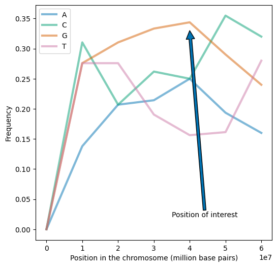

```python
fig, ax = plt.subplots()

for base in 'ACGT':
    ax.plot(bases_chr1['Position'],bases_chr1[base],linewidth=3,label=base,alpha=0.5)
ax.set_xlabel('Position in the chromosome (million base pairs)')
ax.set_ylabel('Frequency')
ax.legend()
ax.annotate('Position of interest', xy=(4e07,0.33),
            xytext=(3.5e07,0.02),arrowprops={})
```